# eEDB-011-2024-3

- **Grupo 02**:
  - Aline Bini
  - Ana Lívia Franco
  - Ana Priss
  - João Squinelato
  - Marcelo Pena
  - Thais Siqueira
- [Github](https://github.com/Squinelato/eEDB-011-2024-3)

`Ingestão De Dados | Agosto 2024`

## Atividade 02: Ingestão e ETL com linguagem de programação (Python)

- Utilizar linguagem de programação Python para ingestão e tratamento de dados.
  - Pacotes adicionais podem ser utilizados (exceto Spark)
  - Tratamento de dados não deve ser realizado via SQL
- Realizar a ingestão de todas as base de dados em um banco de dados relacional open source. Pode ser utilizado qualquer banco de dado sendo algumas sugestões:
  - MySQL
  - Postgre
  - ClickHouse
- Gerar uma tabela final com os dados tratados e unidos.
  - O tratamento de dados deve ser realizado através da linguagem de programação Python
- Adicionar as seguintes camadas de processamento, dentro do próprio banco de dados ou em disco local. A Camada Delivery deve obrigatoriamente ter estar também no formato de uma tabela final dentro do banco de dados relacional:
  - RAW – formato dos dados livre
  - Trusted – formato de dados em Parquet ou ORC or AVRO (indicado Parquet)
  - Delivery– formato de dados em Parquet ou ORC or AVRO (indicado Parquet)

## Comentários

- Foi utilizado o Jupyter Notebook para realizar a atividade, com o objetivo de proporcionar um ambiente interativo que permitisse a análise e manipulação de dados de forma dinâmica e eficiente

## Library Imports

```python
import pandas as pd
import numpy as np
import json
import os

from sqlalchemy import create_engine
from unidecode import unidecode
from hashlib import sha1
```

## Database

Para esta atividade, foi provisionada uma instância RDS na AWS para a criação do banco de dados

Também, foi criado um único banco de dados para armazenar todas as camadas, uma vez que o conjunto de dados era relativamente pequeno

```python
with open('credentials.json') as file:
    credentials = json.load(file)
```

```python
user = credentials['user']
password = credentials['password']
host = credentials['host']
port = credentials['port']
database = 'mydb'
```

```python
connection = f"mysql+pymysql://{user}:{password}@{host}:{port}/{database}"
```

## **Raw**

### **Banks file**

```python
banks_csv_path = './trzd/Bancos/EnquadramentoInicia_v2_alterado_manualmente_revisado.csv'
rwzd_banks = pd.read_csv(banks_csv_path, sep='\t', encoding='utf8', dtype=str)
rwzd_banks.head()
```

|  | Segmento | CNPJ | Nome |
| --- | --- | --- | --- |
| 0 | S1 | 0 | BANCO DO BRASIL - PRUDENCIAL |
| 1 | S1 | 60746948 | BRADESCO - PRUDENCIAL |
| 2 | S1 | 30306294 | BTG PACTUAL - PRUDENCIAL |
| 3 | S1 | 360305 | CAIXA ECONOMICA FEDERAL - PRUDENCIAL |
| 4 | S1 | 60872504 | ITAU - PRUDENCIAL |

```python
rwzd_banks.info()
```

```
<class 'pandas.core.frame.DataFrame'>
RangeIndex: 1474 entries, 0 to 1473
Data columns (total 3 columns):
 #   Column    Non-Null Count  Dtype
---  ------    --------------  -----
 0   Segmento  1474 non-null   object
 1   CNPJ      1474 non-null   object
 2   Nome      1474 non-null   object
dtypes: object(3)
memory usage: 34.7+ KB
```

```python
rwzd_banks.to_parquet('./raw/bank/data.parquet', engine='pyarrow', compression='snappy')
```

### **Employees file**

```python
employees_csv_path = './trzd/Empregados/glassdoor_consolidado_join_match_v2.csv'
rwzd_employees = pd.read_csv(employees_csv_path, sep='|', encoding='utf-8', dtype=str)
rwzd_employees.head(2)
```

|  | employer_name | reviews_count | culture_count | salaries_count | benefits_count | employer-website | employer-headquarters | employer-founded | employer-industry | employer-revenue | ... | Diversidade e inclusão | Qualidade de vida | Alta liderança | Remuneração e benefícios | Oportunidades de carreira | Recomendam para outras pessoas(%) | Perspectiva positiva da empresa(%) | Segmento | Nome | match_percent |
| --- | --- | --- | --- | --- | --- | --- | --- | --- | --- | --- | --- | --- | --- | --- | --- | --- | --- | --- | --- | --- | --- |
| 0 | BNP Paribas | 13000 | 4100 | 20000 | 3600 | http://www.group.bnpparibas | Paris, França | 2000.0 | /Explorar/melhores-serviços-bancários-e-de-cré... | Mais de US$ 10 bilhões | ... | 4.0 | 3.8 | 3.4 | 3.4 | 3.5 | 77.0 | 63.0 | S3 | BNP PARIBAS | 100 |
| 1 | BTG Pactual | 1600 | 683 | 2800 | 635 | http://www.btgpactual.com | São Paulo, Brasil | NaN | /Explorar/melhores-gestão-de-ativos-e-investim... | Desconhecida/não se aplica | ... | 3.5 | 2.8 | 3.7 | 4.4 | 4.2 | 78.0 | 73.0 | S1 | BTG PACTUAL | 100 |

2 rows × 23 columns

```python
rwzd_employees.info()
```

```
<class 'pandas.core.frame.DataFrame'>
RangeIndex: 34 entries, 0 to 33
Data columns (total 23 columns):
 #   Column                              Non-Null Count  Dtype
---  ------                              --------------  -----
 0   employer_name                       34 non-null     object
 1   reviews_count                       34 non-null     object
 2   culture_count                       34 non-null     object
 3   salaries_count                      34 non-null     object
 4   benefits_count                      34 non-null     object
 5   employer-website                    34 non-null     object
 6   employer-headquarters               34 non-null     object
 7   employer-founded                    28 non-null     object
 8   employer-industry                   34 non-null     object
 9   employer-revenue                    34 non-null     object
 10  url                                 34 non-null     object
 11  Geral                               34 non-null     object
 12  Cultura e valores                   34 non-null     object
 13  Diversidade e inclusão              34 non-null     object
 14  Qualidade de vida                   34 non-null     object
 15  Alta liderança                      34 non-null     object
 16  Remuneração e benefícios            34 non-null     object
 17  Oportunidades de carreira           34 non-null     object
 18  Recomendam para outras pessoas(%)   34 non-null     object
 19  Perspectiva positiva da empresa(%)  34 non-null     object
 20  Segmento                            34 non-null     object
 21  Nome                                34 non-null     object
 22  match_percent                       34 non-null     object
dtypes: object(23)
memory usage: 6.2+ KB
```

```python
rwzd_employees.to_parquet('./raw/employee/data.parquet', engine='pyarrow', compression='snappy')
```

### **Claims**

Carregando todos os arquivos de reclamações e os unindo em uma única tabela

```python
list_df_claims = []
claims_dir = './trzd/Reclamações'

for file in os.listdir(claims_dir):
    full_path = os.path.join(claims_dir, file)
    print(f'Processing file: {full_path}')

    claim = pd.read_csv(full_path, sep=';', encoding='utf-8', dtype=str)
    list_df_claims.append(claim)

rwzd_claims = pd.concat(list_df_claims)
```

```
Processing file: ./trzd/Reclamações\2021_tri_01.csv
Processing file: ./trzd/Reclamações\2021_tri_02.csv
Processing file: ./trzd/Reclamações\2021_tri_03.csv
Processing file: ./trzd/Reclamações\2021_tri_04.csv
Processing file: ./trzd/Reclamações\2022_tri_01.csv
Processing file: ./trzd/Reclamações\2022_tri_03.csv
Processing file: ./trzd/Reclamações\2022_tri_04.csv
```

```python
rwzd_claims.head(2)
```

|  | Ano | Trimestre | Categoria | Tipo | CNPJ IF | Instituição financeira | Índice | Quantidade de reclamações reguladas procedentes | Quantidade de reclamações reguladas - outras | Quantidade de reclamações não reguladas | Quantidade total de reclamações | Quantidade total de clientes – CCS e SCR | Quantidade de clientes – CCS | Quantidade de clientes – SCR | Unnamed: 14 |
| --- | --- | --- | --- | --- | --- | --- | --- | --- | --- | --- | --- | --- | --- | --- | --- |
| 0 | 2021 | 1º | Grupo Secundário | Conglomerado |  | ABC-BRASIL (conglomerado) |  | 2 | 3 | 4 | 9 | 26230 | 24698 | 3810 | NaN |
| 1 | 2021 | 1º | Grupo Secundário | Conglomerado |  | AGIBANK (conglomerado) | 54,79 | 58 | 140 | 73 | 271 | 1058431 | 790848 | 693843 | NaN |

```python
rwzd_claims.info()
```

```
<class 'pandas.core.frame.DataFrame'>
Index: 918 entries, 0 to 153
Data columns (total 15 columns):
 #   Column                                           Non-Null Count  Dtype
---  ------                                           --------------  -----
 0   Ano                                              918 non-null    object
 1   Trimestre                                        918 non-null    object
 2   Categoria                                        918 non-null    object
 3   Tipo                                             918 non-null    object
 4   CNPJ IF                                          918 non-null    object
 5   Instituição financeira                           918 non-null    object
 6   Índice                                           918 non-null    object
 7   Quantidade de reclamações reguladas procedentes  918 non-null    object
 8   Quantidade de reclamações reguladas - outras     918 non-null    object
 9   Quantidade de reclamações não reguladas          918 non-null    object
 10  Quantidade total de reclamações                  918 non-null    object
 11  Quantidade total de clientes – CCS e SCR         918 non-null    object
 12  Quantidade de clientes – CCS                     918 non-null    object
 13  Quantidade de clientes – SCR                     918 non-null    object
 14  Unnamed: 14                                      0 non-null      object
dtypes: object(15)
memory usage: 114.8+ KB
```

```python
rwzd_claims.to_parquet('./raw/claim/data.parquet', engine='pyarrow', compression='snappy')
```

**Inserção no banco de dados**

```python
engine = create_engine(connection, echo=False)

with engine.begin() as conn:
    rwzd_banks.to_sql(name='rwzd_banks', con=conn, if_exists='append', index=False)
    rwzd_employees.to_sql(name='rwzd_employees', con=conn, if_exists='append', index=False)
    rwzd_claims.to_sql(name='rwzd_claims', con=conn, if_exists='append', index=False)
```

*rwzd_banks:*

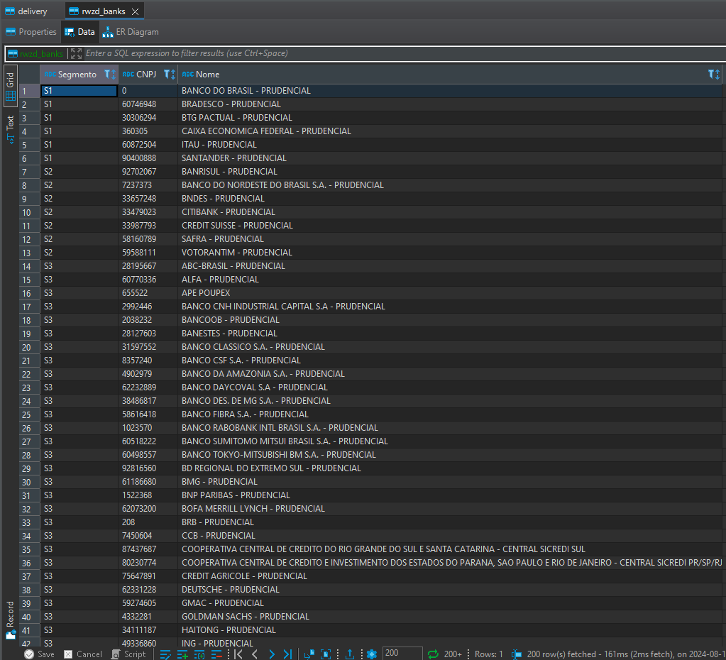

*rwzd_employees:*

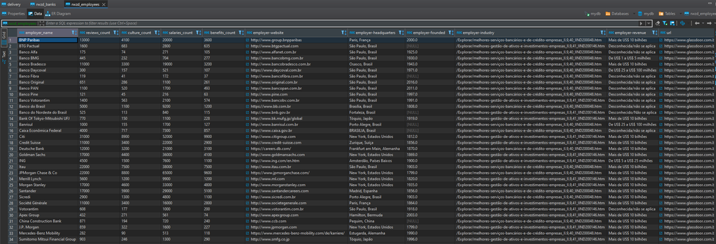

*rwzd_claims:*

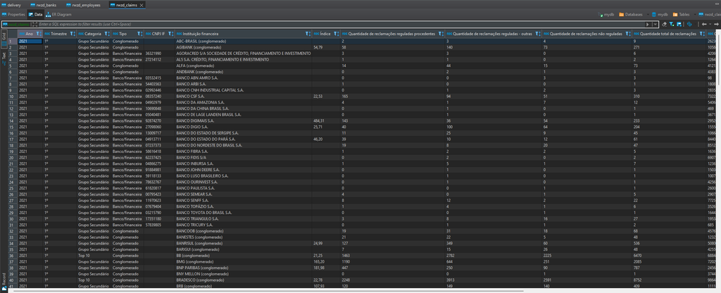

## **Trusted**

### **Banks**

```python
rwzd_bank_path = './raw/bank'
trzd_bank = pd.read_parquet(rwzd_bank_path, engine='pyarrow')
```

Aplicando algumas transformações com o intuito de melhorar a qualidade dos dados:

1 - Renomeando colunas do *dataframe* para inglês e no formato *snake case*

```python
trzd_bank.rename(
    columns={
        'Segmento': 'segment',
        'CNPJ': 'cnpj',
        'Nome': 'financial_institution_name'
    },
    inplace = True
)
```

2 - Para que os dados da coluna *cnpj* estivessem de acordo com seu padrão, os valores incompletos receberam numerais zeros à esquerda até completar 8 dígitos

```python
trzd_bank["cnpj"] = trzd_bank["cnpj"].map(lambda cnpj: cnpj.zfill(8))
```

3 - Criando chave artificial com base no CNPJ e o Segmento da instituição financeira

Foi escolhida a aplicação de uma hash para fins de uniformidade e segurança

```python
trzd_bank["bank_document_id"] = trzd_bank["cnpj"] + trzd_bank["segment"]
trzd_bank["bank_document_id"] = trzd_bank["bank_document_id"].map(
    lambda id: sha1(id.encode("utf-8")).hexdigest())
```

```python
trzd_bank.head()
```

|  | segment | cnpj | financial_institution_name | bank_document_id |
| --- | --- | --- | --- | --- |
| 0 | S1 | 00000000 | BANCO DO BRASIL - PRUDENCIAL | d9be4941c63af670d63086dcb0849a997e062a64 |
| 1 | S1 | 60746948 | BRADESCO - PRUDENCIAL | 2f59bebc86f6b4dd5628043cac240c6e6a6f651d |
| 2 | S1 | 30306294 | BTG PACTUAL - PRUDENCIAL | 110ffbf347c0837827daf658f4f97950ebe9f741 |
| 3 | S1 | 00360305 | CAIXA ECONOMICA FEDERAL - PRUDENCIAL | 587e4dca521e8c4426371a29658419ecb0087262 |
| 4 | S1 | 60872504 | ITAU - PRUDENCIAL | 4b6e5b20d113f3415704fd6a998f2e4500340b18 |

Armazendo o dataframe na camada Trusted

```python
trzd_bank.to_parquet('./trusted/bank/data.parquet', engine='pyarrow', compression='snappy')
```

### **Employees**

```python
rwzd_employee_path = './raw/employee'
trzd_employee = pd.read_parquet(rwzd_employee_path, engine='pyarrow')
```

Aplicando algumas transformações com o intuito de melhorar a qualidade dos dados:

1 - Renomeando colunas do *dataframe* para inglês e no formato *snake case*

```python
trzd_employee.rename(
    columns={
        'employer-website': 'employer_website',
        'employer-headquarters': 'employer_headquarters',
        'employer-founded': 'employer_founded',
        'employer-industry': 'employer_industry',
        'employer-revenue': 'employer_revenue',
        'Geral': 'general_score',
        'Cultura e valores': 'culture_values_score',
        'Diversidade e inclusão': 'diversity_inclusion_score',
        'Qualidade de vida': 'life_quality_score',
        'Alta liderança': 'senior_leadership_score',
        'Remuneração e benefícios': 'compensation_benefits_score',
        'Oportunidades de carreira': 'career_opportunities_score',
        'Recomendam para outras pessoas(%)': 'recommendation_score',
        'Perspectiva positiva da empresa(%)': 'company_positive_score',
        'Segmento': 'segment',
        'Nome': 'financial_institution_name'
    },
    inplace=True
)
```

2 - Alterando os tipos das colunas do *dataframe* para tipos mais *apropriados*

```python
trzd_employee = trzd_employee.astype({
    'employer_name': 'str',
    'reviews_count': 'int64',
    'culture_count': 'int64',
    'salaries_count': 'int64',
    'benefits_count': 'int64',
    'employer_website': 'str',
    'employer_headquarters': 'str',
    'employer_founded': 'str',
    'employer_industry': 'str',
    'employer_revenue': 'str',
    'url': 'str',
    'general_score': 'float64',
    'culture_values_score': 'float64',
    'diversity_inclusion_score': 'float64',
    'life_quality_score': 'float64',
    'senior_leadership_score': 'float64',
    'compensation_benefits_score': 'float64',
    'career_opportunities_score': 'float64',
    'recommendation_score': 'float64',
    'company_positive_score': 'float64',
    'segment': 'str',
    'financial_institution_name': 'str',
    'match_percent': 'int8'
})
```

3 - Tratando campo *employer_founded* para remover casas decimais

```python
trzd_employee["employer_founded"] =  trzd_employee["employer_founded"].str.replace(
    '\..*',
    '',
    regex=True
)
```

4 - Removendo acentos do campos *financial_institution_name*

```python
trzd_employee['financial_institution_name'] = trzd_employee['financial_institution_name'].map(
    lambda x: unidecode(x)
)
```

5 - Criando chave artificial com base no nome da instituição financeira

```python
trzd_employee['bank_name_id'] = trzd_employee['financial_institution_name'].str.lower()
trzd_employee['bank_name_id'] = trzd_employee['bank_name_id'].str.replace(" ", "")
trzd_employee['bank_name_id'] = trzd_employee['bank_name_id'].map(
    lambda x: sha1(x.encode('utf-8')).hexdigest())
```

```python
trzd_employee.head()
```

|  | employer_name | reviews_count | culture_count | salaries_count | benefits_count | employer_website | employer_headquarters | employer_founded | employer_industry | employer_revenue | ... | life_quality_score | senior_leadership_score | compensation_benefits_score | career_opportunities_score | recommendation_score | company_positive_score | segment | financial_institution_name | match_percent | bank_name_id |
| --- | --- | --- | --- | --- | --- | --- | --- | --- | --- | --- | --- | --- | --- | --- | --- | --- | --- | --- | --- | --- | --- |
| 0 | BNP Paribas | 13000 | 4100 | 20000 | 3600 | http://www.group.bnpparibas | Paris, França | 2000 | /Explorar/melhores-serviços-bancários-e-de-cré... | Mais de US$ 10 bilhões | ... | 3.8 | 3.4 | 3.4 | 3.5 | 77.0 | 63.0 | S3 | BNP PARIBAS | 100 | 0612d12173005ce00d9c10800a27985a1e75997e |
| 1 | BTG Pactual | 1600 | 683 | 2800 | 635 | http://www.btgpactual.com | São Paulo, Brasil | None | /Explorar/melhores-gestão-de-ativos-e-investim... | Desconhecida/não se aplica | ... | 2.8 | 3.7 | 4.4 | 4.2 | 78.0 | 73.0 | S1 | BTG PACTUAL | 100 | cdd80a41f223ad9a4236b42c6c1c465c41908aed |
| 2 | Banco Alfa | 175 | 74 | 271 | 105 | http://www.alfanet.com.br | São Paulo, Brasil | 1925 | /Explorar/melhores-serviços-bancários-e-de-cré... | Desconhecida/não se aplica | ... | 3.1 | 2.8 | 3.8 | 2.7 | 68.0 | 47.0 | S3 | ALFA | 100 | 1f7d72cc0ecb87cb6225c2979f3ccbeaf7cd0c33 |
| 3 | Banco BMG | 445 | 232 | 704 | 277 | http://www.bancobmg.com.br | São Paulo, Brasil | 1930 | /Explorar/melhores-serviços-bancários-e-de-cré... | De US$ 1 a US$ 5 milhões | ... | 3.7 | 3.6 | 4.2 | 3.5 | 79.0 | 63.0 | S3 | BMG | 100 | c89e80ee154b6215c5dc790d93590f620e1ec45d |
| 4 | Banco Bradesco | 11000 | 3300 | 19000 | 3200 | http://www.bancobradesco.com.br | Osasco, Brasil | 1943 | /Explorar/melhores-serviços-bancários-e-de-cré... | Mais de US$ 10 bilhões | ... | 3.4 | 3.4 | 4.3 | 3.8 | 81.0 | 66.0 | S1 | BRADESCO | 100 | dd2b7d97678a3cb8b5a9f5e5bf60907d29293298 |

5 rows × 24 columns

Armazendo o dataframe na camada Trusted

```python
trzd_employee.to_parquet('./trusted/employee/data.parquet', engine='pyarrow', compression='snappy')
```

### **Claims**

```python
rwzd_claim_path = './raw/claim'
trzd_claim = pd.read_parquet(rwzd_claim_path, engine='pyarrow')
```

Aplicando algumas transformações com o intuito de melhorar a qualidade dos dados:

1 - Removendo coluna sem dados

```python
trzd_claim.drop(columns=['Unnamed: 14'], inplace=True)
```

2 - Renomendo colunas do *dataframe* para inglês e no formato *snake case*

```python
trzd_claim.rename(
    columns={
        'Ano': 'year',
        'Trimestre': 'quarter',
        'Categoria': 'category',
        'Tipo': 'type',
        'CNPJ IF': 'cnpj',
        'Instituição financeira': 'financial_institution_name',
        'Índice': 'index',
        'Quantidade de reclamações reguladas procedentes': 'number_of_regulated_proceeding_complaints',
        'Quantidade de reclamações reguladas - outras': 'number_of_regulated_other_complaints',
        'Quantidade de reclamações não reguladas': 'number_of_unregulated_complaints',
        'Quantidade total de reclamações': 'total_number_of_complaints',
        'Quantidade total de clientes – CCS e SCR': 'total_number_of_ccs_and_scr_customers',
        'Quantidade de clientes – CCS': 'number_of_ccs_customers',
        'Quantidade de clientes – SCR': 'number_of_scr_customers'
    },
    inplace=True
)
```

3 - Tratando a coluna *index*

- Devido a valores com separação por pontos na cada do milhar, foi necessário realizar a remoção (e.g.: 2.000,00 passa a ser 2000,00)
- A fim de converter mais tarde para o tipo float, a vírgula da casa dos decimais foi substituída por ponto
- Por fim, string vazias foram substituídas por NaN

```python
trzd_claim["index"] = trzd_claim["index"].str.replace('.', '')
trzd_claim["index"] = trzd_claim["index"].str.replace(',', '.')
trzd_claim["index"] = trzd_claim["index"].replace(' ', np.nan)
```

4 - Tratando as colunas *quarter* e *cnpj*

- O caracter º foi removido da coluna *quarter*
- Para que os dados da coluna *cnpj* estivessem de acordo com seu padrão, os valores incompletos receberam numerais zeros à esquerda até completar 8 dígitos

```python
trzd_claim["quarter"] = trzd_claim["quarter"].str.replace('º', '')
trzd_claim['cnpj'] = trzd_claim['cnpj'].str.replace(" ", "")
trzd_claim["cnpj"] = trzd_claim["cnpj"].map(
    lambda cnpj: cnpj.zfill(8) if len(cnpj) > 0 and len(cnpj) < 8 else cnpj)
```

5 - Tratando as colunas *total_number_of_ccs_and_scr_customers*, *number_of_ccs_customers* e *number_of_scr_customers*, as quais continham strings vazias

Assim, as strings vazias foram substituídas por valores NaN e convertidas para float, possibilitando a conversão para o tipo inteiro mais adiante

```python
trzd_claim['total_number_of_ccs_and_scr_customers'] = trzd_claim['total_number_of_ccs_and_scr_customers'].replace(
    ' ', np.nan).astype(float)
trzd_claim['number_of_ccs_customers'] = trzd_claim['number_of_ccs_customers'].replace(
    ' ', np.nan).astype(float)
trzd_claim['number_of_scr_customers'] = trzd_claim['number_of_scr_customers'].replace(
    ' ', np.nan).astype(float)
```

6 - Alterando os tipos das colunas do *dataframe* para tipos mais *apropriados*

```python
trzd_claim = trzd_claim.astype({
    'year': 'str',
    'quarter': 'uint8',
    'category': 'str',
    'type': 'str',
    'cnpj': 'str',
    'financial_institution_name': 'str',
    'index': 'float64',
    'number_of_regulated_proceeding_complaints': 'int64',
    'number_of_regulated_other_complaints': 'int64',
    'number_of_unregulated_complaints': 'int64',
    'total_number_of_complaints': 'int64',
    'total_number_of_ccs_and_scr_customers': pd.Int64Dtype(),
    'number_of_ccs_customers': pd.Int64Dtype(),
    'number_of_scr_customers': pd.Int64Dtype()
})
```

7 - Padronizando o campo *financial_institution_name*

Padrão encontrado " (conglomerado)", que não estava de acordo com o campo *financial_institution_name* em *employees*

```python
trzd_claim['financial_institution_name'] = trzd_claim['financial_institution_name'].str.replace(
    ' (conglomerado)',
    ''
)
```

Remoção de acentos para aumentar a probabilidade de match com os bancos de *employees*

```python
trzd_claim['financial_institution_name'] = trzd_claim['financial_institution_name'].map(
    lambda x: unidecode(x))
```

Casos pontuais encontrados nos nomes

```python
trzd_claim['financial_institution_name'] = trzd_claim['financial_institution_name'].str.replace(
    'BB', 'BANCO DO BRASIL')
trzd_claim['financial_institution_name'] = trzd_claim['financial_institution_name'].str.replace(
    'DAYCOVAL', 'BANCO DAYCOVAL S.A')
trzd_claim['financial_institution_name'] = trzd_claim['financial_institution_name'].str.replace(
    'DEUTSCHE BANK S.A. - BANCO ALEMAO', 'DEUTSCHE')
trzd_claim['financial_institution_name'] = trzd_claim['financial_institution_name'].str.replace(
    'BANCO SUMITOMO MITSUI BRASILEIRO S.A.', 'BANCO SUMITOMO MITSUI BRASIL S.A.')
```

8 - Criando chave artificial com base no nome da instituição financeira

```python
trzd_claim['bank_name_id'] = trzd_claim['financial_institution_name'].str.lower()
trzd_claim['bank_name_id'] = trzd_claim['bank_name_id'].str.replace(" ", "")
trzd_claim['bank_name_id'] = trzd_claim['bank_name_id'].map(
    lambda x: sha1(x.encode('utf-8')).hexdigest())
```

```python
trzd_claim.head()
```

|  | year | quarter | category | type | cnpj | financial_institution_name | index | number_of_regulated_proceeding_complaints | number_of_regulated_other_complaints | number_of_unregulated_complaints | total_number_of_complaints | total_number_of_ccs_and_scr_customers | number_of_ccs_customers | number_of_scr_customers | bank_name_id |
| --- | --- | --- | --- | --- | --- | --- | --- | --- | --- | --- | --- | --- | --- | --- | --- |
| 0 | 2021 | 1 | Grupo Secundário | Conglomerado |  | ABC-BRASIL | NaN | 2 | 3 | 4 | 9 | 26230 | 24698 | 3810 | e59e75522e2fc29a497ee94dfac733ebe7557b68 |
| 1 | 2021 | 1 | Grupo Secundário | Conglomerado |  | AGIBANK | 54.79 | 58 | 140 | 73 | 271 | 1058431 | 790848 | 693843 | 9935e071203e03fbcf8bebc6bf6eed7f348e3a7a |
| 2 | 2021 | 1 | Grupo Secundário | Banco/financeira | 36321990 | AGORACRED S/A SOCIEDADE DE CREDITO, FINANCIAME... | NaN | 3 | 3 | 0 | 6 | 420692 | 129 | 420563 | d14cba42359f43b5fbd61ee3d0faefaa73997b85 |
| 3 | 2021 | 1 | Grupo Secundário | Banco/financeira | 27214112 | AL5 S.A. CREDITO, FINANCIAMENTO E INVESTIMENTO | NaN | 1 | 1 | 0 | 2 | 12645 | 4979 | 10112 | c01ccc940cb107c1e48d2eef610c91c7d0354b2e |
| 4 | 2021 | 1 | Grupo Secundário | Conglomerado |  | ALFA | NaN | 14 | 44 | 15 | 73 | 412135 | 268186 | 145105 | 1f7d72cc0ecb87cb6225c2979f3ccbeaf7cd0c33 |

Armazendo o dataframe na camada Trusted

```python
trzd_claim.to_parquet('./trusted/claim/data.parquet', engine='pyarrow', compression='snappy')
```

**Inserção no banco de dados**

```python
engine = create_engine(connection, echo=False)

with engine.begin() as conn:
    trzd_bank.to_sql(name='trzd_banks', con=conn, if_exists='append', index=False)
    trzd_employee.to_sql(name='trzd_employees', con=conn, if_exists='append', index=False)
    trzd_claim.to_sql(name='trzd_claims', con=conn, if_exists='append', index=False)
```

*trzd_banks:*

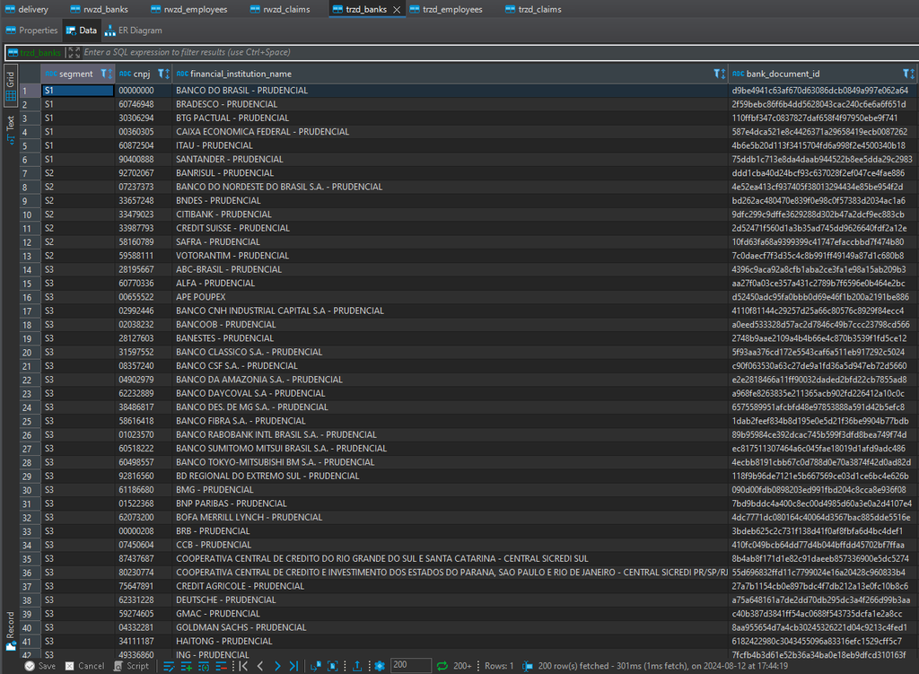

*trzd_employees:*

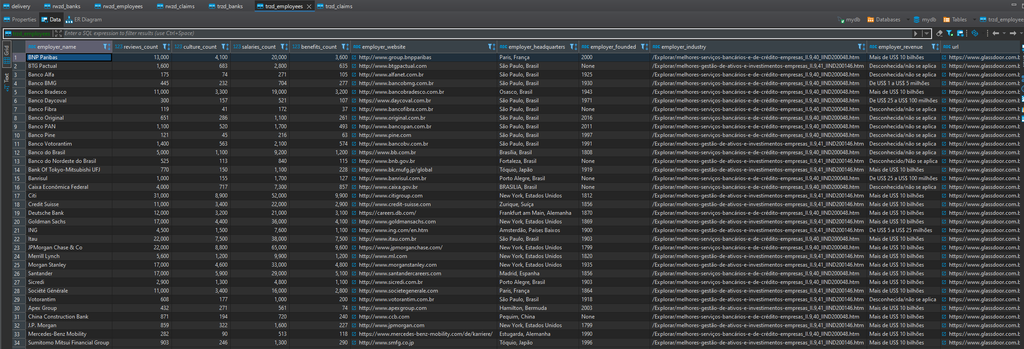

*trzd_claims:*

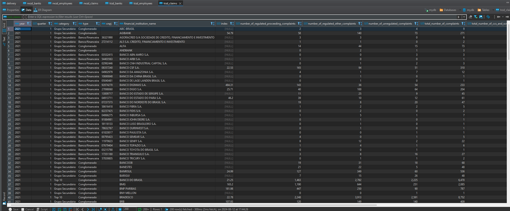

## **Delivery**

```python
trzd_bank_path = './trusted/bank'
banks = pd.read_parquet(trzd_bank_path, engine='pyarrow')

trzd_employee_path = './trusted/employee'
employee = pd.read_parquet(trzd_employee_path, engine='pyarrow')

trzd_claim_path = './trusted/claim'
claims = pd.read_parquet(trzd_claim_path, engine='pyarrow')
```

**Junção entre as tabelas banks e claim através do cnpj**

A coluna *financial_institution_name* foi removida de banks para que não houvesse repetição de coluna

Como esta coluna em claims foi ajustado para estar compatível com employees, foi a escolhida para manter-se no merge

```python
banks = banks.drop(columns=['financial_institution_name'])

banks_claims = pd.merge(claims, banks, on='cnpj', how='inner')

banks_claims.head(2)
```

|  | year | quarter | category | type | cnpj | financial_institution_name | index | number_of_regulated_proceeding_complaints | number_of_regulated_other_complaints | number_of_unregulated_complaints | total_number_of_complaints | total_number_of_ccs_and_scr_customers | number_of_ccs_customers | number_of_scr_customers | bank_name_id | segment | bank_document_id |
| --- | --- | --- | --- | --- | --- | --- | --- | --- | --- | --- | --- | --- | --- | --- | --- | --- | --- |
| 0 | 2021 | 1 | Grupo Secundário | Banco/financeira | 36321990 | AGORACRED S/A SOCIEDADE DE CREDITO, FINANCIAME... | NaN | 3 | 3 | 0 | 6 | 420692 | 129 | 420563 | d14cba42359f43b5fbd61ee3d0faefaa73997b85 | S4 | b5a8f0808f253ba305496155fa6fd50f449e5846 |
| 1 | 2021 | 1 | Grupo Secundário | Banco/financeira | 03532415 | BANCO ABN AMRO S.A. | NaN | 0 | 0 | 3 | 3 | 98 | 71 | 31 | c444a43000c079d0bf4eb83a1dcedefc66e180e7 | S4 | a6966623c9b8e7a3352769e1118e56da6dd3ecb5 |

```python
banks_claims.info()
```

```
<class 'pandas.core.frame.DataFrame'>
RangeIndex: 327 entries, 0 to 326
Data columns (total 17 columns):
 #   Column                                     Non-Null Count  Dtype
---  ------                                     --------------  -----
 0   year                                       327 non-null    object
 1   quarter                                    327 non-null    uint8
 2   category                                   327 non-null    object
 3   type                                       327 non-null    object
 4   cnpj                                       327 non-null    object
 5   financial_institution_name                 327 non-null    object
 6   index                                      47 non-null     float64
 7   number_of_regulated_proceeding_complaints  327 non-null    int64
 8   number_of_regulated_other_complaints       327 non-null    int64
 9   number_of_unregulated_complaints           327 non-null    int64
 10  total_number_of_complaints                 327 non-null    int64
 11  total_number_of_ccs_and_scr_customers      327 non-null    Int64
 12  number_of_ccs_customers                    301 non-null    Int64
 13  number_of_scr_customers                    318 non-null    Int64
 14  bank_name_id                               327 non-null    object
 15  segment                                    327 non-null    object
 16  bank_document_id                           327 non-null    object
dtypes: Int64(3), float64(1), int64(4), object(8), uint8(1)
memory usage: 42.3+ KB
```

**Junção entre as tabelas claim e employees através do bank_name_id**

A coluna _financial_institution*name* foi removida de employee para que não houvesse repetição de coluna

Como esta coluna em claims possui mais linhas, foi a escolhida para manter-se no merge

```python
employee = employee.drop(columns=['financial_institution_name'])

employee_claims = pd.merge(claims, employee, on='bank_name_id', how='inner')

employee_claims.head(2)
```

|  | year | quarter | category | type | cnpj | financial_institution_name | index | number_of_regulated_proceeding_complaints | number_of_regulated_other_complaints | number_of_unregulated_complaints | ... | culture_values_score | diversity_inclusion_score | life_quality_score | senior_leadership_score | compensation_benefits_score | career_opportunities_score | recommendation_score | company_positive_score | segment | match_percent |
| --- | --- | --- | --- | --- | --- | --- | --- | --- | --- | --- | --- | --- | --- | --- | --- | --- | --- | --- | --- | --- | --- |
| 0 | 2021 | 1 | Grupo Secundário | Conglomerado |  | ALFA | NaN | 14 | 44 | 15 | ... | 3.2 | 3.2 | 3.1 | 2.8 | 3.8 | 2.7 | 68.0 | 47.0 | S3 | 100 |
| 1 | 2021 | 1 | Grupo Secundário | Banco/financeira | 07237373 | BANCO DO NORDESTE DO BRASIL S.A. | NaN | 19 | 8 | 20 | ... | 4.4 | 4.3 | 4.3 | 4.1 | 4.2 | 4.0 | 90.0 | 83.0 | S2 | 100 |

2 rows × 37 columns

Criando chave artificial com base no CNPJ e o Segmento da instituição financeira

```python
employee_claims["bank_document_id"] = employee_claims["cnpj"] + employee_claims["segment"]
employee_claims["bank_document_id"] = employee_claims["bank_document_id"].map(
    lambda id: sha1(id.encode("utf-8")).hexdigest())
```

```python
employee_claims.info()
```

```
<class 'pandas.core.frame.DataFrame'>
RangeIndex: 154 entries, 0 to 153
Data columns (total 38 columns):
 #   Column                                     Non-Null Count  Dtype
---  ------                                     --------------  -----
 0   year                                       154 non-null    object
 1   quarter                                    154 non-null    uint8
 2   category                                   154 non-null    object
 3   type                                       154 non-null    object
 4   cnpj                                       154 non-null    object
 5   financial_institution_name                 154 non-null    object
 6   index                                      85 non-null     float64
 7   number_of_regulated_proceeding_complaints  154 non-null    int64
 8   number_of_regulated_other_complaints       154 non-null    int64
 9   number_of_unregulated_complaints           154 non-null    int64
```

[output cut: 30 more lines]

**Junção entre as tabelas banks_claims e employee_claims através do bank_document_id**

Verificando quais as colunas que employee_claims não possui em comum com banks_claims para evitar repetição de colunas ao realizar a junção

As colunas de banks_claims foram mantidas pois é a que possui maior quantidade de linhas

```python
columns_to_add_employee_claims = list(set(employee_claims.columns) - set(banks_claims.columns))
columns_to_add_employee_claims.append('bank_document_id')
columns_to_add_employee_claims
```

```
['employer_name',
 'employer_website',
 'employer_industry',
 'senior_leadership_score',
 'diversity_inclusion_score',
 'general_score',
 'url',
 'compensation_benefits_score',
 'career_opportunities_score',
 'company_positive_score',
 'employer_revenue',
 'match_percent',
 'culture_values_score',
 'employer_headquarters',
 'reviews_count',
 'benefits_count',
 'salaries_count',
 'life_quality_score',
 'recommendation_score',
 'employer_founded',
 'culture_count',
 'bank_document_id']
```

Junção das tabelas e remoção de itens duplicados

```python
dlzd_bank_employment_satisfaction = pd.merge(
    banks_claims,
    employee_claims[columns_to_add_employee_claims],
    on='bank_document_id',
    how='inner'
)

dlzd_bank_employment_satisfaction.drop_duplicates(ignore_index=True, inplace=True)
```

Em relação à atividade anterior, o número final de registros na tabela aumentou de 13 para 16. Esse incremento se deve ao tratamento aplicado nas colunas, incluindo um início de padronização dos dados, bem como a correção de inconsistências e a eliminação de duplicatas.

```python
dlzd_bank_employment_satisfaction.info()
```

```
<class 'pandas.core.frame.DataFrame'>
RangeIndex: 16 entries, 0 to 15
Data columns (total 38 columns):
 #   Column                                     Non-Null Count  Dtype
---  ------                                     --------------  -----
 0   year                                       16 non-null     object
 1   quarter                                    16 non-null     uint8
 2   category                                   16 non-null     object
 3   type                                       16 non-null     object
 4   cnpj                                       16 non-null     object
 5   financial_institution_name                 16 non-null     object
 6   index                                      0 non-null      float64
 7   number_of_regulated_proceeding_complaints  16 non-null     int64
 8   number_of_regulated_other_complaints       16 non-null     int64
 9   number_of_unregulated_complaints           16 non-null     int64
```

[output cut: 30 more lines]

```python
dlzd_bank_employment_satisfaction.head(2)
```

|  | year | quarter | category | type | cnpj | financial_institution_name | index | number_of_regulated_proceeding_complaints | number_of_regulated_other_complaints | number_of_unregulated_complaints | ... | match_percent | culture_values_score | employer_headquarters | reviews_count | benefits_count | salaries_count | life_quality_score | recommendation_score | employer_founded | culture_count |
| --- | --- | --- | --- | --- | --- | --- | --- | --- | --- | --- | --- | --- | --- | --- | --- | --- | --- | --- | --- | --- | --- |
| 0 | 2021 | 1 | Grupo Secundário | Banco/financeira | 07237373 | BANCO DO NORDESTE DO BRASIL S.A. | NaN | 19 | 8 | 20 | ... | 100 | 4.4 | Fortaleza, Brasil | 525 | 115 | 840 | 4.3 | 90.0 | None | 113 |
| 1 | 2021 | 1 | Grupo Secundário | Banco/financeira | 58616418 | BANCO FIBRA S.A. | NaN | 1 | 2 | 2 | ... | 100 | 4.3 | São Paulo, Brasil | 119 | 37 | 172 | 3.8 | 87.0 | None | 41 |

2 rows × 38 columns

**Inserção no banco de dados**

```python
engine = create_engine(connection, echo=False)

with engine.begin() as conn:
    dlzd_bank_employment_satisfaction.to_sql(
        name='dlzd_bank_employment_satisfaction',
        con=conn, if_exists='append',
        index=False
    )
```

Tabela *dlzd_bank_employment_satisfaction*:

[figure not shown]

## Generate Python file

Exemplo

```python
%%writefile ./scripts/testes.py
print('hello world')
```

[output not shown]

Dúvidas?